# modeling_part

## Bevezetés, Összefogalás:

Ahol nem volt szükséges one-hot encoding ott nem csináltam (az elején) a vége felé az K-mean modelltől kezdve már csináltam.

Az overal findingom az az, hogy nincs nagy predikciós ereje egyik modellnek sem.  
* Ez jelentheti azt, hogy random a viselkedésük a usereknek?  
* Neked van valamilyen ötleted, hogy mit kéne csinálni?

Nem mindegyik package szükséges, csak ezeket szoktam nagyjából használni úgyhogy az eleején betöltöm őket. Ami bizots szókséges az a Caret és data.table

## Data preparation:

Read in the data: (replace file directory with your path)

```r
data <- fread("C:/Users/menyh/OneDrive - Central European University/final_project/for_model.csv", stringsAsFactors = T)
```

Creating some variables for later:

```r
data[,broker_yes_no:= ifelse(broker == "no_broker", "no", "yes")]
data[, broker_1_0:= ifelse(broker == "no_broker", 0, 1)]
#data <- data[broker_yes_no == "yes"]
```

Creating factor variables for logit/ multinomial logit:

```r
data <- data.table(data)

cols <- c("simple_prod", "sophisticated", "leveraged", "fx", "broker_yes_no")
data[,(cols):=lapply(.SD, as.factor),.SDcols=cols]

summary(data)
```

```
##     fill_id         segment             how_independent
##  Min.   : 257   investor:1580   consult         :1033
##  1st Qu.:4391   starter :3569   following       : 697
##  Median :4515   trader  :1205   myself          :4496
##  Mean   :4812                   wantprofessional: 128
##  3rd Qu.:5920
##  Max.   :8159
##
##        trading_exp   how_much_money      how_often        market
##  basics      :1290   less:4239      daily     :1642   mayor  :5097
##  beginer     :2767   more:2115      mediumterm:2692   smaller:1257
##  complex     :1518                  weeks     :2020
##  professional: 779
##
##
##
##  simple_prod sophisticated leveraged fx       investor_protection
##  0: 947      0:4215        0:4262    0:4690   riskier: 965
##  1:5407      1:2139        1:2092    1:1664   want   :5389
##
##
##
##
##
##          broker           first_rec           sec_rec     broker_yes_no
##  no_broker  :4441   strateo    :3014   swiss      :2008   no :4441
##  strateo    : 651   degiro     : 961   strateo    :1448   yes:1913
##  degiro     : 415   etoro      : 697   internaxx  :1104
##  saxo       : 206   saxo       : 572   saxo       : 808
##  internaxx  : 171   swiss      : 478   degiro     : 531
##  interactive: 154   interactive: 392   interactive: 136
##  (Other)    : 316   (Other)    : 240   (Other)    : 319
##    broker_1_0
##  Min.   :0.0000
##  1st Qu.:0.0000
##  Median :0.0000
##  Mean   :0.3011
##  3rd Qu.:1.0000
##  Max.   :1.0000
##
```

## 1st Modeling part: predicting ratio of choosing a broker/ who is going to choose a broker:

Test and train split:

```r
set.seed(512)
train_indices <- createDataPartition(y = data$broker_yes_no,
                                     times = 1,
                                     p = 0.8,
                                     list = FALSE)
data_train <- data[train_indices, ]
data_test <- data[-train_indices, ]
```

### Lasso:

```r
lasso <- train(broker_yes_no ~
                 segment +
                 how_independent +
                 trading_exp +
                 how_much_money +
                 how_often +
                 market +
                 simple_prod +
                 sophisticated +
                 leveraged +
                 fx +
                 investor_protection,
               intercept = FALSE,
               method = "glmnet",
               metric = "ROC",
               data = data_train,
               trControl = trainControl(method = "cv",
                                        number = 5,
                                        classProbs = TRUE,
                                        summaryFunction=twoClassSummary,
                                        selectionFunction = "oneSE"),
               tuneGrid = expand.grid(alpha=1,
                                      lambda=c(0.001,
                                               0.002,
                                               0.003,
                                               0.004,
                                               0.005,
                                               0.01,
                                               0.02,
                                               0.03,
                                               0.035,
                                               0.04,
                                               0.045,
                                               0.05)))
```

```r
lasso
```

```
## glmnet
##
## 5084 samples
##   11 predictor
##    2 classes: 'no', 'yes'
##
## No pre-processing
## Resampling: Cross-Validated (5 fold)
## Summary of sample sizes: 4066, 4068, 4067, 4068, 4067
## Resampling results across tuning parameters:
##
##   lambda  ROC        Sens      Spec
##   0.001   0.5646575  0.999437  0.0019607843
##   0.002   0.5649654  1.000000  0.0006535948
##   0.003   0.5643653  1.000000  0.0000000000
##   0.004   0.5638287  1.000000  0.0000000000
##   0.005   0.5632564  1.000000  0.0000000000
##   0.010   0.5620942  1.000000  0.0000000000
##   0.020   0.5577107  1.000000  0.0000000000
##   0.030   0.5506848  1.000000  0.0000000000
##   0.035   0.5484910  1.000000  0.0000000000
##   0.040   0.5436979  1.000000  0.0000000000
##   0.045   0.5372822  1.000000  0.0000000000
##   0.050   0.5329307  1.000000  0.0000000000
##
## Tuning parameter 'alpha' was held constant at a value of 1
## ROC was used to select the optimal model using  the one SE rule.
## The final values used for the model were alpha = 1 and lambda = 0.02.
```

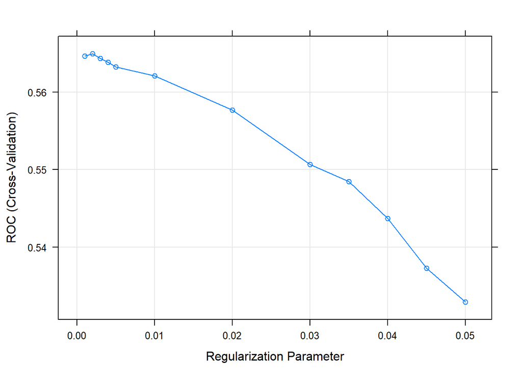

```r
plot(lasso)
```

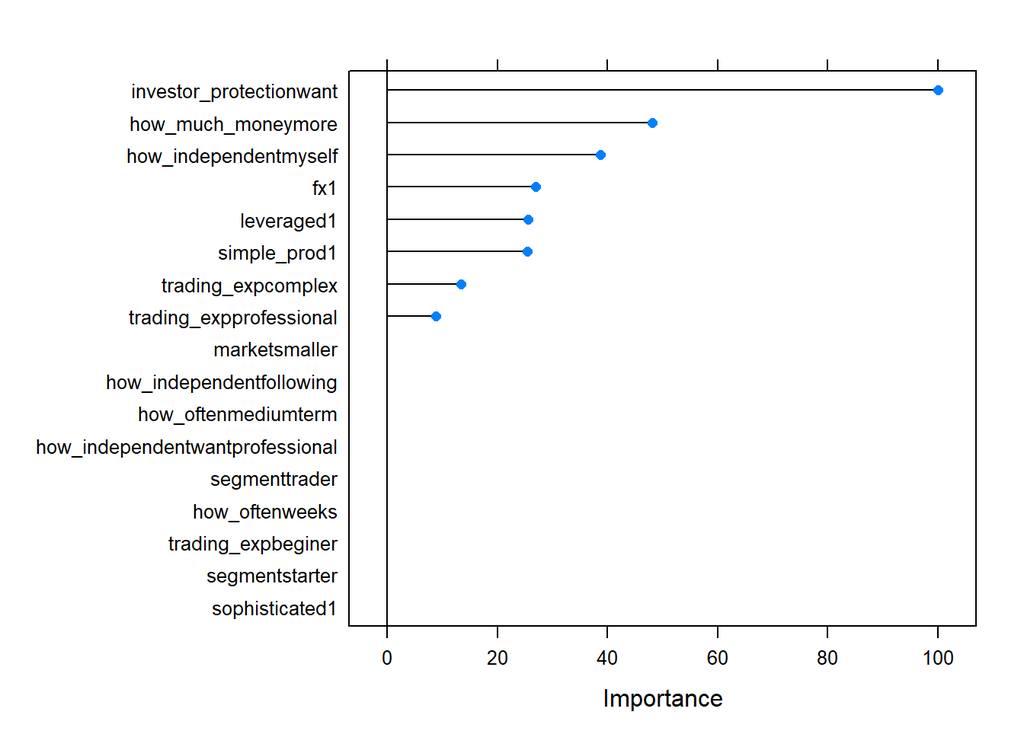

```r
plot(varImp(lasso))
```

```r
#coef(lasso$finalModel)
```

Predicting on the test set:

```r
data_test$lasso_pred <- predict.train(lasso, newdata = data_test)

data_test$lasso_pred_prob <- predict.train(lasso, newdata = data_test, type = "prob")$yes

threshold <- 0.3
data_test[, lasso_pred:= ifelse(lasso_pred_prob > threshold, "yes", "no")]
```

```r
data_test$broker_yes_no <- as.factor(data_test$broker_yes_no)
data_test$lasso_pred <- as.factor(data_test$lasso_pred)

confusionMatrix(data_test$lasso_pred, data_test$broker_yes_no)
```

```
## Confusion Matrix and Statistics
##
##           Reference
## Prediction  no yes
##        no  363 123
##        yes 525 259
##
##                Accuracy : 0.4898
##                  95% CI : (0.4619, 0.5176)
##     No Information Rate : 0.6992
##     P-Value [Acc > NIR] : 1
##
##                   Kappa : 0.0668
##  Mcnemar's Test P-Value : <2e-16
##
##             Sensitivity : 0.4088
##             Specificity : 0.6780
##          Pos Pred Value : 0.7469
##          Neg Pred Value : 0.3304
##              Prevalence : 0.6992
##          Detection Rate : 0.2858
##    Detection Prevalence : 0.3827
##       Balanced Accuracy : 0.5434
##
##        'Positive' Class : no
##
```

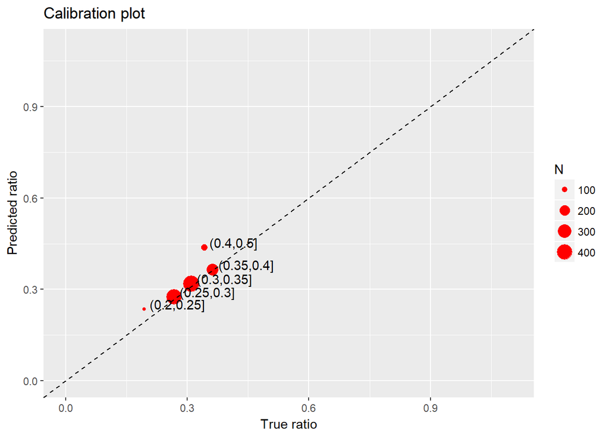

```r
data_test[, broker_binary:= ifelse(broker_yes_no == "yes", 1, 0)]

group <- cut(data_test$lasso_pred_prob, c(0, 0.05, 0.1, 0.15, 0.2, 0.25, 0.3, 0.35, 0.4, 0.5, 0.55, 0.6, 0.7, 0.8, 0.9, 1), include.lowest = TRUE)

data_test[, prediction_normal_group := group]

calibrateplot <- data_test[, .(N = .N, true_mean = mean(broker_binary), predicted_mean = mean(lasso_pred_prob)), by = prediction_normal_group]

ggplot(calibrateplot, aes(x= true_mean, y=predicted_mean)) + geom_point(aes(size = N), color = "red")+ geom_text(aes(label=prediction_normal_group),hjust=-0.1, vjust=0) + geom_abline(slope = 1, linetype = 2) + coord_cartesian(xlim = c(0, 1.1), ylim = c(0,1.1)) + labs(x="True ratio", y="Predicted ratio") + ggtitle("Calibration plot")
```

### Decision Tree:

```r
train_control <- trainControl(method = "cv",
                              number = 5,
                              classProbs = TRUE,
                              selectionFunction = "oneSE",
                              summaryFunction=twoClassSummary)
```

```r
tree_model <- train(broker_yes_no ~ segment + how_independent + trading_exp + how_much_money + how_often + market + simple_prod + sophisticated + leveraged + fx + investor_protection,
                    method = "rpart",
                    data = data_train,
                    tuneGrid = data.frame("cp" = c(0.0001, 0.001, 0.01, 0.1)),
                    trControl = train_control,
                    metric = "ROC")
```

```r
tree_model
```

```
## CART
##
## 5084 samples
##   11 predictor
##    2 classes: 'no', 'yes'
##
## No pre-processing
## Resampling: Cross-Validated (5 fold)
## Summary of sample sizes: 4067, 4068, 4066, 4067, 4068
## Resampling results across tuning parameters:
##
##   cp     ROC        Sens       Spec
##   1e-04  0.5640239  0.9200729  0.10450704
##   1e-03  0.5538893  0.9907121  0.01697856
##   1e-02  0.5000000  1.0000000  0.00000000
##   1e-01  0.5000000  1.0000000  0.00000000
##
## ROC was used to select the optimal model using  the one SE rule.
## The final value used for the model was cp = 1e-04.
```

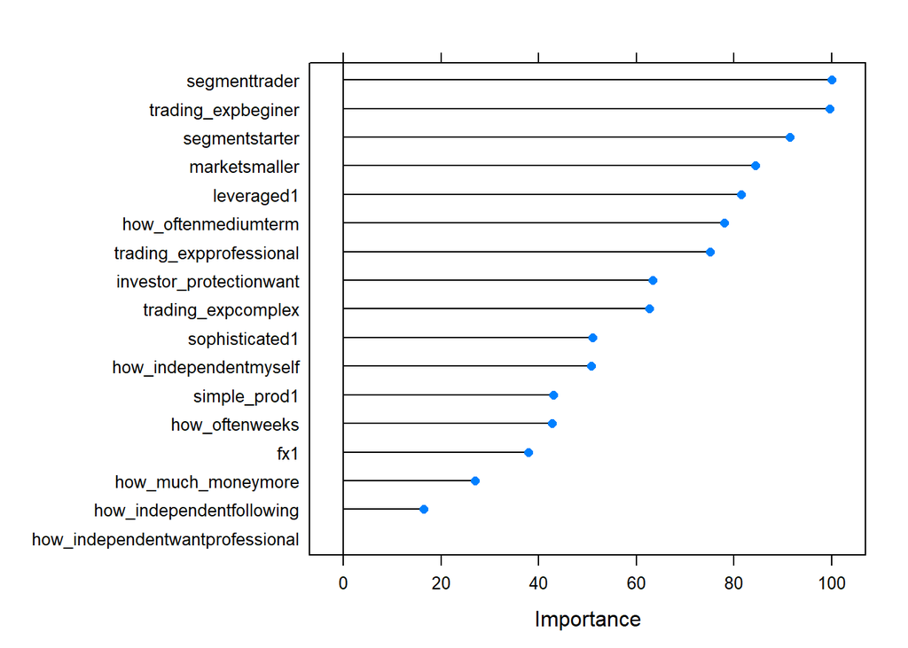

```r
plot(varImp(tree_model))
```

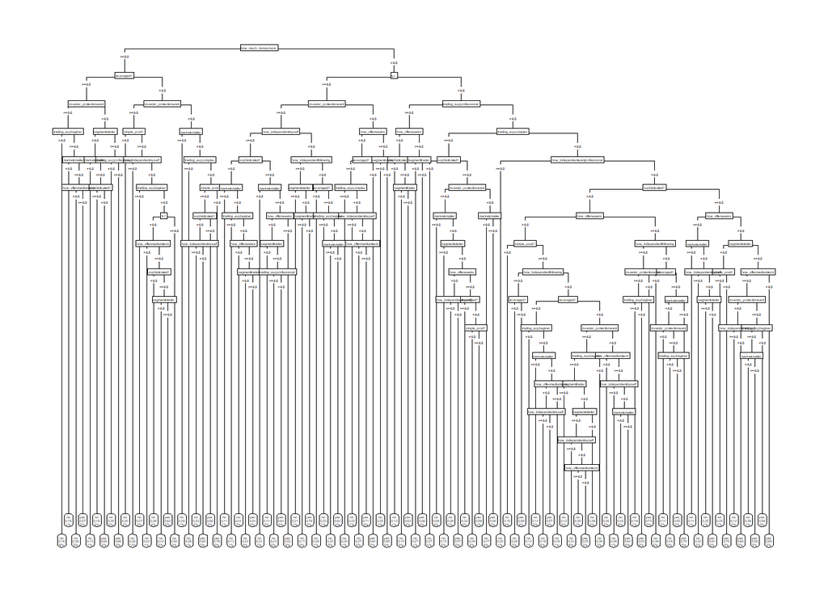

```r
rpart.plot(tree_model$finalModel, box.palette=0, type = 5)
```

Prediction on the test set:

```r
data_test$tree_pred <- predict.train(tree_model, newdata = data_test)

data_test$tree_pred_probs <- predict.train(tree_model, newdata = data_test, type = "prob")$yes
```

Calibration plot:

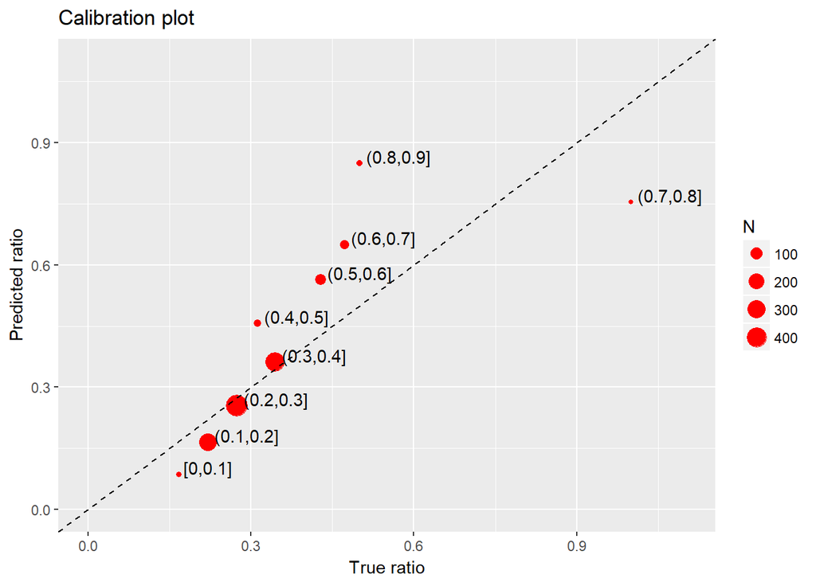

```r
data_test[, broker_binary:= ifelse(broker_yes_no == "yes", 1, 0)]

group <- cut(data_test$tree_pred_probs, c(0, 0.1, 0.2, 0.3, 0.4, 0.5, 0.6, 0.7, 0.8, 0.9, 1), include.lowest = TRUE)

data_test[, prediction_normal_group := group]

calibrateplot <- data_test[, .(N = .N, true_mean = mean(broker_binary), predicted_mean = mean(tree_pred_probs)), by = prediction_normal_group]

ggplot(calibrateplot, aes(x= true_mean, y=predicted_mean)) + geom_point(aes(size = N), color = "red")+ geom_text(aes(label=prediction_normal_group),hjust=-0.1, vjust=0) + geom_abline(slope = 1, linetype = 2) + coord_cartesian(xlim = c(0, 1.1), ylim = c(0,1.1)) + labs(x="True ratio", y="Predicted ratio") + ggtitle("Calibration plot")
```

### RandomForest:

```r
train_control <- trainControl(method = "cv",
                              number = 5,
                              classProbs = TRUE,
                              summaryFunction=twoClassSummary)
```

```r
rf_model <- train(broker_yes_no ~ segment + how_independent + trading_exp + how_much_money + how_often +
                      market + simple_prod + sophisticated + leveraged + fx + investor_protection,
                  method = "rf",
                  data = data_train,
                  trControl = train_control,
                  tuneGrid = data.frame(mtry = c(2, 3, 4, 5, 6, 7, 8, 9, 10, 11)),
                  importance = T,
                  metric = "ROC")
```

```r
rf_model
```

```
## Random Forest
##
## 5084 samples
##   11 predictor
##    2 classes: 'no', 'yes'
##
## No pre-processing
## Resampling: Cross-Validated (5 fold)
## Summary of sample sizes: 4068, 4067, 4066, 4067, 4068
## Resampling results across tuning parameters:
##
##   mtry  ROC        Sens       Spec
##    2    0.5073271  1.0000000  0.00000000
##    3    0.5121319  0.9974672  0.01175193
##    4    0.5165170  0.9921190  0.04376317
##    5    0.5198051  0.9743876  0.06858913
##    6    0.5210713  0.9549680  0.10191182
##    7    0.5221961  0.9380824  0.12411914
##    8    0.5215263  0.9271041  0.14174491
##    9    0.5227569  0.9175341  0.15023312
##   10    0.5249229  0.9107783  0.16068212
##   11    0.5243825  0.9068394  0.16068425
##
## ROC was used to select the optimal model using the largest value.
## The final value used for the model was mtry = 10.
```

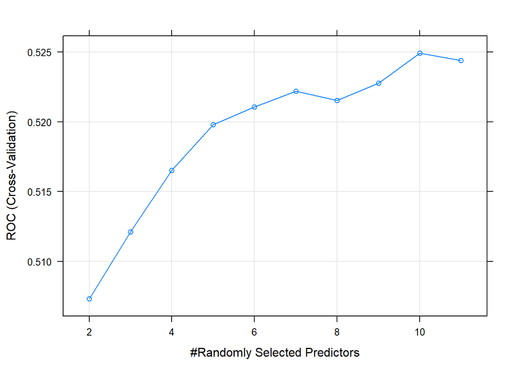

```r
plot(rf_model)
```

Variable importance plot:

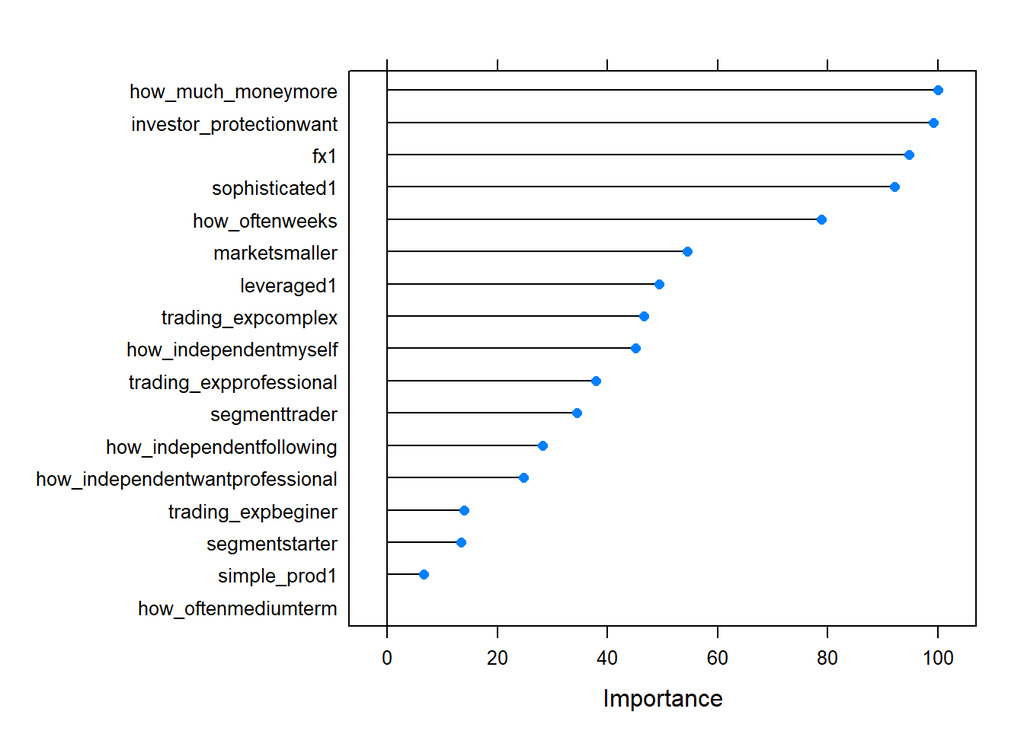

```r
plot(varImp(rf_model))
```

```r
data_test$rf_pred <- predict.train(rf_model, newdata = data_test)

data_test$rf_pred_probs <- predict.train(rf_model, newdata = data_test, type = "prob")$yes
```

Calibration plot:

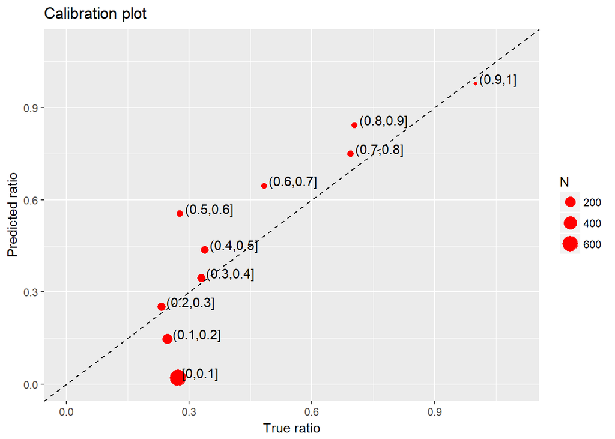

```r
data_test[, broker_binary:= ifelse(broker_yes_no == "yes", 1, 0)]

group <- cut(data_test$rf_pred_probs, c(0, 0.1, 0.2, 0.3, 0.4, 0.5, 0.6, 0.7, 0.8, 0.9, 1), include.lowest = TRUE)

data_test[, prediction_normal_group := group]

calibrateplot <- data_test[, .(N = .N, true_mean = mean(broker_binary), predicted_mean = mean(rf_pred_probs)), by = prediction_normal_group]

ggplot(calibrateplot, aes(x= true_mean, y=predicted_mean)) + geom_point(aes(size = N), color = "red")+ geom_text(aes(label=prediction_normal_group),hjust=-0.1, vjust=0) + geom_abline(slope = 1, linetype = 2) + coord_cartesian(xlim = c(0, 1.1), ylim = c(0,1.1)) + labs(x="True ratio", y="Predicted ratio") + ggtitle("Calibration plot")
```

## 2nd modeling part: Predicting actual brokers:

### Data prep:

```r
data <- data[broker != "no_broker"]

summary(data$broker)
```

```
##          bgl    comdirect       degiro        etoro       ig_com
##           11           25          415           46           21
##  interactive    internaxx  markets_com    no_broker        oanda
##          154          171           11            0           32
##   peperstone      plus500         saxo      strateo        swiss
##           23            6          206          651          109
##   tastyworks tradestation
##           21           11
```

```r
data$broker <- factor(data$broker)

set.seed(512)
train_indices <- createDataPartition(y = data$broker,
                                     times = 1,
                                     p = 0.8,
                                     list = FALSE)
data_train <- data[train_indices, ]
data_test <- data[-train_indices, ]
```

Ha mindent beraknánk abba a kategóriába, ami a legnagyobb kategória, akkor a következő accuracy-t kapnánk:  
* Jelen esetben a legtöbben Strateót választanak (651-en)

```r
count(data[broker == 'strateo'])/length(data$broker)
```

```
##           n
## 1 0.3403032
```

Ezt kell a modelljeinknek megverni, hogy jobb predikciót tegyenek, mint a legeslegegyszerűbb naiv elképzelés.  
Ezt hívják úgy, hogy: `no information rate`

### multinomial logit:

Ezt a részt a végén láthatod, mert one-hot encodoltam hozzá az adatokat, és itt az még nincs meg csinálva.

### Tree model:

```r
train_control <- trainControl(method = "cv",
                              number = 5,
                              classProbs = TRUE,
                              selectionFunction = "oneSE")
```

```r
tree_model <- train(broker ~ segment + how_independent + trading_exp + how_much_money + how_often + market + simple_prod + sophisticated + leveraged + fx + investor_protection,
                    method = "rpart",
                    data = data_train,
                    tuneGrid = data.frame("cp" = c(0.0001, 0.0002, 0.0005, 0.0007, 0.0008, 0.0009, 0.001, 0.002, 0.003, 0.01, 0.015, 0.1, 0.3)),
                    trControl = train_control)
```

```r
tree_model
```

```
## CART
##
## 1535 samples
##   11 predictor
##   16 classes: 'bgl', 'comdirect', 'degiro', 'etoro', 'ig_com', 'interactive', 'internaxx', 'markets_com', 'oanda', 'peperstone', 'plus500', 'saxo', 'strateo', 'swiss', 'tastyworks', 'tradestation'
##
## No pre-processing
## Resampling: Cross-Validated (5 fold)
## Summary of sample sizes: 1230, 1226, 1225, 1230, 1229
## Resampling results across tuning parameters:
##
##   cp      Accuracy   Kappa
##   0.0001  0.3342238  0.09212240
##   0.0002  0.3342238  0.09212240
##   0.0005  0.3407366  0.09601070
##   0.0007  0.3492081  0.10098063
##   0.0008  0.3511753  0.10331688
##   0.0009  0.3537940  0.10199365
##   0.0010  0.3511710  0.09915636
##   0.0020  0.3688102  0.10665069
##   0.0030  0.3772564  0.11642136
##   0.0100  0.3661683  0.08854596
##   0.0150  0.3641864  0.08325439
##   0.1000  0.3394232  0.00000000
##   0.3000  0.3394232  0.00000000
##
## Accuracy was used to select the optimal model using  the one SE rule.
## The final value used for the model was cp = 0.003.
```

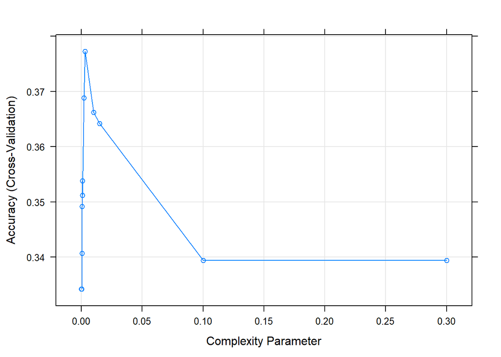

```r
plot(tree_model)
```

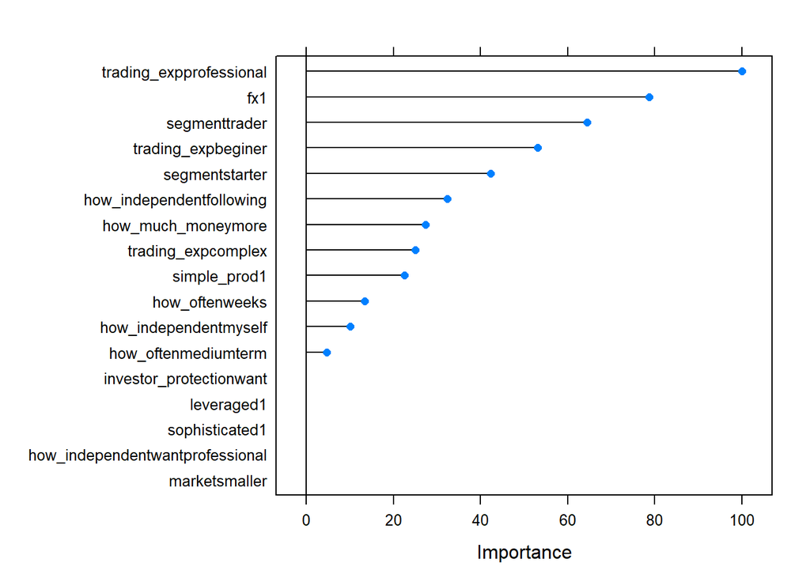

```r
plot(varImp(tree_model))
```

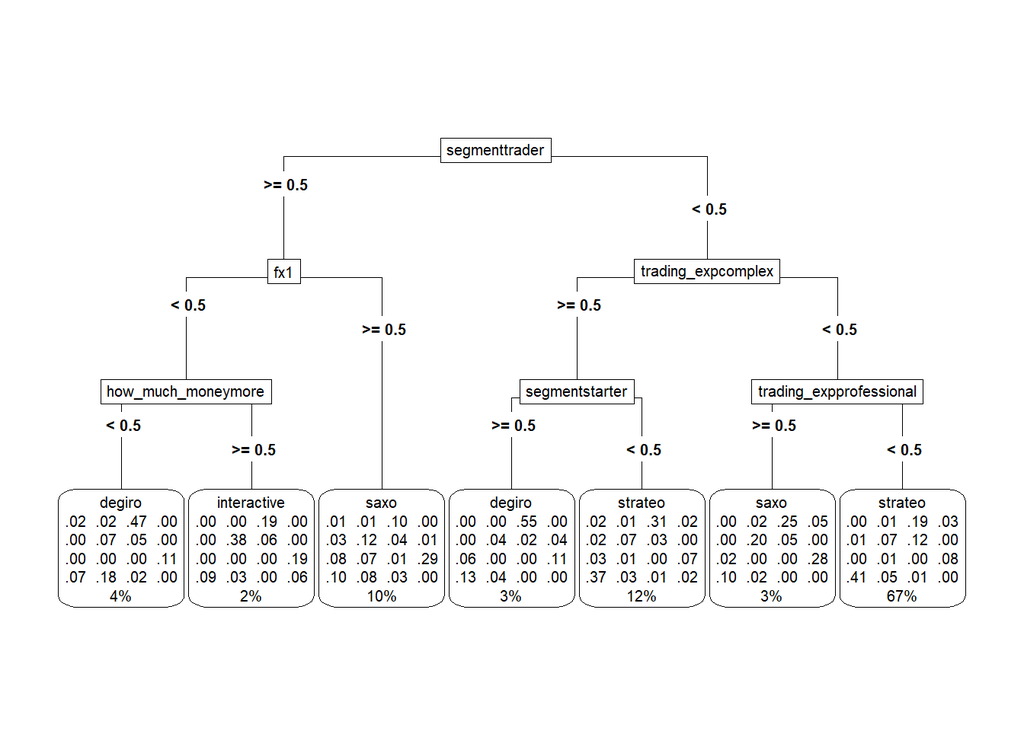

```r
rpart.plot(tree_model$finalModel, box.palette=0, type = 5)
```

```r
data_test$tree_pred <- predict.train(tree_model, newdata = data_test)

tree_pred_probs <- predict.train(tree_model, newdata = data_test, type = "prob")
```

ConfusionMatrix on the test set:

```r
confusionMatrix(data_test$tree_pred, data_test$broker)
```

```
## Confusion Matrix and Statistics
##
##               Reference
## Prediction     bgl comdirect degiro etoro ig_com interactive internaxx
##   bgl            0         0      0     0      0           0         0
##   comdirect      0         0      0     0      0           0         0
##   degiro         0         1     13     0      0           3         0
##   etoro          0         0      0     0      0           0         0
##   ig_com         0         0      0     0      0           0         0
##   interactive    0         0      1     0      1           1         0
##   internaxx      0         0      0     0      0           0         0
##   markets_com    0         0      0     0      0           0         0
##   oanda          0         0      0     0      0           0         0
##   peperstone     0         0      0     0      0           0         0
##   plus500        0         0      0     0      0           0         0
##   saxo           0         1      6     2      0           8         1
##   strateo        2         3     63     7      3          18        33
##   swiss          0         0      0     0      0           0         0
##   tastyworks     0         0      0     0      0           0         0
##   tradestation   0         0      0     0      0           0         0
##               Reference
## Prediction     markets_com oanda peperstone plus500 saxo strateo swiss
##   bgl                    0     0          0       0    0       0     0
##   comdirect              0     0          0       0    0       0     0
##   degiro                 0     0          0       0    8       3     2
##   etoro                  0     0          0       0    0       0     0
##   ig_com                 0     0          0       0    0       0     0
##   interactive            0     0          0       0    3       1     0
##   internaxx              0     0          0       0    0       0     0
##   markets_com            0     0          0       0    0       0     0
##   oanda                  0     0          0       0    0       0     0
##   peperstone             0     0          0       0    0       0     0
##   plus500                0     0          0       0    0       0     0
##   saxo                   0     3          3       1    6       4     6
##   strateo                2     3          1       0   24     122    13
##   swiss                  0     0          0       0    0       0     0
##   tastyworks             0     0          0       0    0       0     0
##   tradestation           0     0          0       0    0       0     0
##               Reference
## Prediction     tastyworks tradestation
```

[output cut: 68 more lines]

```
## Pos Pred Value               0.4094          NaN               NaN
## Neg Pred Value               0.9000      0.94444           0.98942
## Prevalence                   0.3439      0.05556           0.01058
## Detection Rate               0.3228      0.00000           0.00000
## Detection Prevalence         0.7884      0.00000           0.00000
## Balanced Accuracy            0.6144      0.50000           0.50000
##                      Class: tradestation
## Sensitivity                     0.000000
## Specificity                     1.000000
## Pos Pred Value                       NaN
## Neg Pred Value                  0.994709
## Prevalence                      0.005291
## Detection Rate                  0.000000
## Detection Prevalence            0.000000
## Balanced Accuracy               0.500000
```

RandomForest:

### RandomForest:

```r
train_control <- trainControl(method = "cv",
                              number = 5,
                              classProbs = TRUE)
```

```r
rf_model <- train(broker ~
                    segment +
                    how_independent +
                    trading_exp +
                    how_much_money +
                    how_often +
                    market +
                    simple_prod +
                    sophisticated +
                    leveraged +
                    fx +
                    investor_protection,
                  method = "rf",
                  data = data_train,
                  trControl = train_control,
                  tuneGrid = data.frame(mtry = c(2, 3, 4, 5, 7, 9, 11)),
                  importance = T)
```

```r
rf_model
```

```
## Random Forest
##
## 1535 samples
##   11 predictor
##   16 classes: 'bgl', 'comdirect', 'degiro', 'etoro', 'ig_com', 'interactive', 'internaxx', 'markets_com', 'oanda', 'peperstone', 'plus500', 'saxo', 'strateo', 'swiss', 'tastyworks', 'tradestation'
##
## No pre-processing
## Resampling: Cross-Validated (5 fold)
## Summary of sample sizes: 1227, 1227, 1229, 1228, 1229
## Resampling results across tuning parameters:
##
##   mtry  Accuracy   Kappa
##    2    0.3648282  0.08767138
##    3    0.3570105  0.09117898
##    4    0.3517903  0.09771482
##    5    0.3296721  0.08069444
##    7    0.3074903  0.07027373
##    9    0.2892427  0.05543135
##   11    0.2846845  0.05328677
##
## Accuracy was used to select the optimal model using the largest value.
## The final value used for the model was mtry = 2.
```

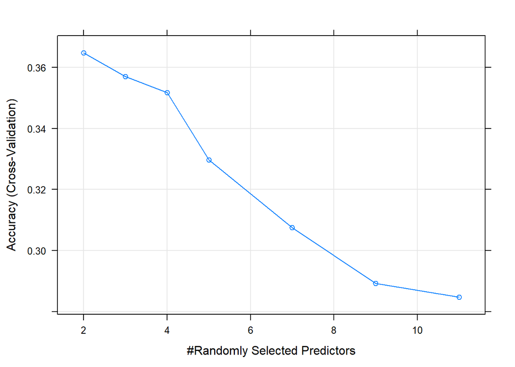

```r
plot(rf_model)
```

Variable importance plot:

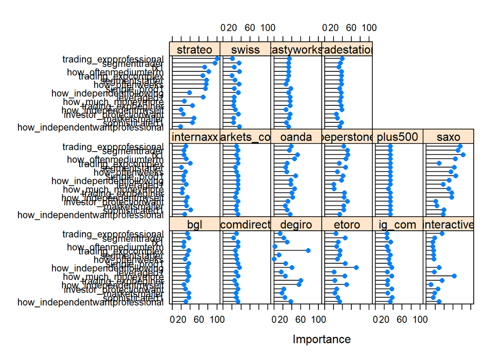

```r
plot(varImp(rf_model))
```

```r
data_test$rf_pred <- predict.train(rf_model, newdata = data_test)

rf_pred_probs <- predict.train(rf_model, newdata = data_test, type = "prob")
```

Accuracy and ConfusionMatrix on the test set:  
* Accuracy is almost the same as on the train set so we accept the model.

```r
confusionMatrix(data_test$rf_pred, data_test$broker)
```

```
## Confusion Matrix and Statistics
##
##               Reference
## Prediction     bgl comdirect degiro etoro ig_com interactive internaxx
##   bgl            0         0      0     0      0           0         0
##   comdirect      0         0      0     0      0           0         0
##   degiro         0         0     14     0      1           5         0
##   etoro          0         0      0     0      0           0         0
##   ig_com         0         0      0     0      0           0         0
##   interactive    0         1      0     0      0           2         0
##   internaxx      0         0      0     0      0           0         0
##   markets_com    0         0      0     0      0           0         0
##   oanda          0         0      0     0      0           0         0
##   peperstone     0         0      0     0      0           0         0
##   plus500        0         0      0     0      0           0         0
##   saxo           0         0      1     0      0           5         1
##   strateo        2         4     68     9      3          18        33
##   swiss          0         0      0     0      0           0         0
##   tastyworks     0         0      0     0      0           0         0
##   tradestation   0         0      0     0      0           0         0
##               Reference
## Prediction     markets_com oanda peperstone plus500 saxo strateo swiss
##   bgl                    0     0          0       0    0       0     0
##   comdirect              0     0          0       0    0       0     0
##   degiro                 0     1          1       0    6      10     5
##   etoro                  0     0          0       0    0       0     0
##   ig_com                 0     0          0       0    0       0     0
##   interactive            0     0          0       0    3       0     0
##   internaxx              0     0          0       0    1       0     0
##   markets_com            0     0          0       0    0       0     0
##   oanda                  0     0          0       0    0       0     0
##   peperstone             0     0          0       0    0       0     0
##   plus500                0     0          0       0    0       0     0
##   saxo                   0     2          2       0    3       2     2
##   strateo                2     3          1       1   28     118    14
##   swiss                  0     0          0       0    0       0     0
##   tastyworks             0     0          0       0    0       0     0
##   tradestation           0     0          0       0    0       0     0
##               Reference
## Prediction     tastyworks tradestation
```

[output cut: 68 more lines]

```
## Pos Pred Value               0.3819          NaN               NaN
## Neg Pred Value               0.8261      0.94444           0.98942
## Prevalence                   0.3439      0.05556           0.01058
## Detection Rate               0.3122      0.00000           0.00000
## Detection Prevalence         0.8175      0.00000           0.00000
## Balanced Accuracy            0.5688      0.50000           0.50000
##                      Class: tradestation
## Sensitivity                     0.000000
## Specificity                     1.000000
## Pos Pred Value                       NaN
## Neg Pred Value                  0.994709
## Prevalence                      0.005291
## Detection Rate                  0.000000
## Detection Prevalence            0.000000
## Balanced Accuracy               0.500000
```

ConfusionMatrix on the test set:

```r
prop.table(confusionMatrix(data_test$rf_pred, data_test$broker)$table, 1)
```

```
##               Reference
## Prediction             bgl   comdirect      degiro       etoro      ig_com
##   bgl
##   comdirect
##   degiro       0.000000000 0.000000000 0.318181818 0.000000000 0.022727273
##   etoro
##   ig_com
##   interactive  0.000000000 0.166666667 0.000000000 0.000000000 0.000000000
##   internaxx    0.000000000 0.000000000 0.000000000 0.000000000 0.000000000
##   markets_com
##   oanda
##   peperstone
##   plus500
##   saxo         0.000000000 0.000000000 0.055555556 0.000000000 0.000000000
##   strateo      0.006472492 0.012944984 0.220064725 0.029126214 0.009708738
##   swiss
##   tastyworks
##   tradestation
##               Reference
## Prediction     interactive   internaxx markets_com       oanda  peperstone
##   bgl
##   comdirect
##   degiro       0.113636364 0.000000000 0.000000000 0.022727273 0.022727273
##   etoro
##   ig_com
##   interactive  0.333333333 0.000000000 0.000000000 0.000000000 0.000000000
##   internaxx    0.000000000 0.000000000 0.000000000 0.000000000 0.000000000
##   markets_com
##   oanda
##   peperstone
##   plus500
##   saxo         0.277777778 0.055555556 0.000000000 0.111111111 0.111111111
##   strateo      0.058252427 0.106796117 0.006472492 0.009708738 0.003236246
##   swiss
##   tastyworks
##   tradestation
##               Reference
## Prediction         plus500        saxo     strateo       swiss  tastyworks
##   bgl
##   comdirect
```

[output cut: 17 more lines]

```
##   comdirect
##   degiro        0.000000000
##   etoro
##   ig_com
##   interactive   0.000000000
##   internaxx     0.000000000
##   markets_com
##   oanda
##   peperstone
##   plus500
##   saxo          0.000000000
##   strateo       0.006472492
##   swiss
##   tastyworks
##   tradestation
```

```r
tuneParam <- expand.grid(nrounds = c(300),
                       max_depth = c(2, 3, 5),
                       eta = c(0.01, 0.05, 0.1),
                       gamma = c(0.1),
                       colsample_bytree = c(0.5, 0.3),
                       min_child_weight = 1,
                       subsample = c(0.7, 0.3))
```

```r
xboost_model <- train(broker ~
                    segment +
                    how_independent +
                    trading_exp +
                    how_much_money +
                    how_often +
                    market +
                    simple_prod +
                    sophisticated +
                    leveraged +
                    fx +
                    investor_protection,
                  method = "xgbTree",
                  data = data_train,
                  trControl = train_control,
                  tuneGrid = tuneParam,
                  importance = T)
```

```r
xboost_model
```

```
## eXtreme Gradient Boosting
##
## 1535 samples
##   11 predictor
##   16 classes: 'bgl', 'comdirect', 'degiro', 'etoro', 'ig_com', 'interactive', 'internaxx', 'markets_com', 'oanda', 'peperstone', 'plus500', 'saxo', 'strateo', 'swiss', 'tastyworks', 'tradestation'
##
## No pre-processing
## Resampling: Cross-Validated (5 fold)
## Summary of sample sizes: 1229, 1228, 1227, 1229, 1227
## Resampling results across tuning parameters:
##
##   eta   max_depth  colsample_bytree  subsample  Accuracy   Kappa
##   0.01  2          0.3               0.3        0.3752199  0.10183335
##   0.01  2          0.3               0.7        0.3810938  0.11306495
##   0.01  2          0.5               0.3        0.3817283  0.11784825
##   0.01  2          0.5               0.7        0.3856477  0.12381800
##   0.01  3          0.3               0.3        0.3765250  0.10598796
##   0.01  3          0.3               0.7        0.3771616  0.10744378
##   0.01  3          0.5               0.3        0.3817283  0.11821786
##   0.01  3          0.5               0.7        0.3830376  0.12131791
##   0.01  5          0.3               0.3        0.3732782  0.10146538
##   0.01  5          0.3               0.7        0.3778152  0.10999487
##   0.01  5          0.5               0.3        0.3797823  0.11797349
##   0.01  5          0.5               0.7        0.3810959  0.12274322
##   0.05  2          0.3               0.3        0.3850004  0.13180061
##   0.05  2          0.3               0.7        0.3908701  0.14168987
##   0.05  2          0.5               0.3        0.3895501  0.14458891
##   0.05  2          0.5               0.7        0.3843575  0.13675137
##   0.05  3          0.3               0.3        0.3745897  0.12159395
##   0.05  3          0.3               0.7        0.3810980  0.13393945
##   0.05  3          0.5               0.3        0.3778300  0.13148927
##   0.05  3          0.5               0.7        0.3758841  0.13178888
##   0.05  5          0.3               0.3        0.3739127  0.12845546
##   0.05  5          0.3               0.7        0.3667508  0.11970179
##   0.05  5          0.5               0.3        0.3628398  0.12094446
##   0.05  5          0.5               0.7        0.3452628  0.10360431
##   0.10  2          0.3               0.3        0.3830545  0.14084418
##   0.10  2          0.3               0.7        0.3817367  0.13709568
##   0.10  2          0.5               0.3        0.3797866  0.13702028
##   0.10  2          0.5               0.7        0.3771849  0.13513404
##   0.10  3          0.3               0.3        0.3693630  0.12571091
##   0.10  3          0.3               0.7        0.3674107  0.12629883
##   0.10  3          0.5               0.3        0.3543749  0.11272619
##   0.10  3          0.5               0.7        0.3537404  0.11451142
##   0.10  5          0.3               0.3        0.3550137  0.11092415
##   0.10  5          0.3               0.7        0.3511239  0.11343867
##   0.10  5          0.5               0.3        0.3387396  0.10368871
##   0.10  5          0.5               0.7        0.3231043  0.09069644
##
## Tuning parameter 'nrounds' was held constant at a value of 300
##
## Tuning parameter 'gamma' was held constant at a value of 0.1
##
## Tuning parameter 'min_child_weight' was held constant at a value of 1
## Accuracy was used to select the optimal model using the largest value.
## The final values used for the model were nrounds = 300, max_depth = 2,
##  eta = 0.05, gamma = 0.1, colsample_bytree = 0.3, min_child_weight = 1
##  and subsample = 0.7.
```

```r
data_test$xboost_pred <- predict.train(xboost_model, newdata = data_test)

xboost_pred_probs <- predict.train(xboost_model, newdata = data_test, type = "prob")
```

Accuracy and ConfusionMatrix on the test set:

```r
confusionMatrix(data_test$xboost_pred, data_test$broker)
```

```
## Confusion Matrix and Statistics
##
##               Reference
## Prediction     bgl comdirect degiro etoro ig_com interactive internaxx
##   bgl            0         0      0     0      0           0         0
##   comdirect      0         0      0     0      0           0         0
##   degiro         0         1     25     0      2           4         1
##   etoro          0         0      0     0      0           0         0
##   ig_com         0         0      0     0      0           0         0
##   interactive    0         1      1     0      0           3         0
##   internaxx      0         0      0     0      0           0         0
##   markets_com    0         0      0     0      0           0         0
##   oanda          0         0      0     0      0           0         0
##   peperstone     0         0      0     0      0           0         0
##   plus500        0         0      0     0      0           0         0
##   saxo           0         0      4     1      0           5         1
##   strateo        2         3     53     8      2          18        32
##   swiss          0         0      0     0      0           0         0
##   tastyworks     0         0      0     0      0           0         0
##   tradestation   0         0      0     0      0           0         0
##               Reference
## Prediction     markets_com oanda peperstone plus500 saxo strateo swiss
##   bgl                    0     0          0       0    0       0     0
##   comdirect              0     0          0       0    0       0     0
##   degiro                 1     0          0       0    6      16     5
##   etoro                  0     0          0       0    0       0     0
##   ig_com                 0     0          0       0    0       0     0
##   interactive            0     0          0       0    4       1     0
##   internaxx              0     0          0       0    0       0     0
##   markets_com            0     0          0       0    0       0     0
##   oanda                  0     0          0       0    1       0     0
##   peperstone             0     0          0       0    0       0     0
##   plus500                0     0          0       0    0       0     0
##   saxo                   0     3          3       0    3       2     4
##   strateo                1     3          1       0   26     110    12
##   swiss                  0     0          0       1    1       1     0
##   tastyworks             0     0          0       0    0       0     0
##   tradestation           0     0          0       0    0       0     0
##               Reference
## Prediction     tastyworks tradestation
```

[output cut: 68 more lines]

```
## Pos Pred Value               0.4000     0.000000               NaN
## Neg Pred Value               0.8058     0.944000           0.98942
## Prevalence                   0.3439     0.055556           0.01058
## Detection Rate               0.2910     0.000000           0.00000
## Detection Prevalence         0.7275     0.007937           0.00000
## Balanced Accuracy            0.5904     0.495798           0.50000
##                      Class: tradestation
## Sensitivity                     0.000000
## Specificity                     1.000000
## Pos Pred Value                       NaN
## Neg Pred Value                  0.994709
## Prevalence                      0.005291
## Detection Rate                  0.000000
## Detection Prevalence            0.000000
## Balanced Accuracy               0.500000
```

## One hot encoded part part:

Kiindulási alap:

```r
colnames(data)
```

```
##  [1] "fill_id"             "segment"             "how_independent"
##  [4] "trading_exp"         "how_much_money"      "how_often"
##  [7] "market"              "simple_prod"         "sophisticated"
## [10] "leveraged"           "fx"                  "investor_protection"
## [13] "broker"              "first_rec"           "sec_rec"
## [16] "broker_yes_no"       "broker_1_0"
```

```r
data_one_hot <- with(data,
                     data.frame(model.matrix(~segment-1,data),
                                model.matrix(~how_independent-1, data),
                                model.matrix(~trading_exp-1, data),
                                 model.matrix(~how_much_money-1, data),
                                 model.matrix(~how_often-1, data),
                                 model.matrix(~market-1, data),
                                 simple_prod,
                                 sophisticated,
                                 leveraged,
                                 fx,
                                 model.matrix(~investor_protection-1, data),
                                 broker))

data_one_hot <- data.table(data_one_hot)
colnames(data_one_hot)
```

```
##  [1] "segmentinvestor"                 "segmentstarter"
##  [3] "segmenttrader"                   "how_independentconsult"
##  [5] "how_independentfollowing"        "how_independentmyself"
##  [7] "how_independentwantprofessional" "trading_expbasics"
##  [9] "trading_expbeginer"              "trading_expcomplex"
## [11] "trading_expprofessional"         "how_much_moneyless"
## [13] "how_much_moneymore"              "how_oftendaily"
## [15] "how_oftenmediumterm"             "how_oftenweeks"
## [17] "marketmayor"                     "marketsmaller"
## [19] "simple_prod"                     "sophisticated"
## [21] "leveraged"                       "fx"
## [23] "investor_protectionriskier"      "investor_protectionwant"
## [25] "broker"
```

Már 25 olszopunk van, mert minden x-et bináris változóvá alakítottunk.

Test és train split:

```r
train_indices <- createDataPartition(y = data_one_hot$broker,
                                     times = 1,
                                     p = 0.8,
                                     list = FALSE)

data_train_one_hot <- data_one_hot[train_indices, ]
data_test_one_hot <- data_one_hot[-train_indices, ]
```

### SVM model:

```r
tuneParam <- trainControl(method = "cv",
                              number = 5,
                              classProbs = TRUE)


svm_Linear <- train(broker ~ .,
                    data = data_train_one_hot,
                    method = "svmLinear",
                    trControl=tuneParam,
                    preProcess = c("center", "scale"))
```

[output not shown]

```r
svm_Linear
```

```
## Support Vector Machines with Linear Kernel
##
## 1535 samples
##   24 predictor
##   16 classes: 'bgl', 'comdirect', 'degiro', 'etoro', 'ig_com', 'interactive', 'internaxx', 'markets_com', 'oanda', 'peperstone', 'plus500', 'saxo', 'strateo', 'swiss', 'tastyworks', 'tradestation'
##
## Pre-processing: centered (24), scaled (24)
## Resampling: Cross-Validated (5 fold)
## Summary of sample sizes: 1228, 1230, 1227, 1229, 1226
## Resampling results:
##
##   Accuracy   Kappa
##   0.2195614  0.02026357
##
## Tuning parameter 'C' was held constant at a value of 1
```

### Simple decision tree on one-hot-encoded data:

- I was curious wheter the one-hot encoded data gives different results than the deafult data. It turned out gives the same results.
- exactly the same results than without one-hot encoded the variables. Looks like Caret does it for us.

```r
train_control <- trainControl(method = "cv",
                              number = 5,
                              classProbs = TRUE,
                              selectionFunction = "oneSE")

tree_model <- train(broker ~ .,
                    method = "rpart",
                    data = data_train_one_hot,
                    tuneGrid = data.frame("cp" = c(0.0001, 0.0002, 0.0005, 0.0007, 0.0008, 0.0009, 0.001, 0.002, 0.003, 0.01, 0.015, 0.1)),
                    trControl = train_control)
```

```r
tree_model
```

```
## CART
##
## 1535 samples
##   24 predictor
##   16 classes: 'bgl', 'comdirect', 'degiro', 'etoro', 'ig_com', 'interactive', 'internaxx', 'markets_com', 'oanda', 'peperstone', 'plus500', 'saxo', 'strateo', 'swiss', 'tastyworks', 'tradestation'
##
## No pre-processing
## Resampling: Cross-Validated (5 fold)
## Summary of sample sizes: 1228, 1228, 1229, 1227, 1228
## Resampling results across tuning parameters:
##
##   cp      Accuracy   Kappa
##   0.0001  0.3621931  0.1304010
##   0.0002  0.3621931  0.1304010
##   0.0005  0.3615416  0.1295040
##   0.0007  0.3595872  0.1254173
##   0.0008  0.3595979  0.1208726
##   0.0009  0.3622058  0.1207534
##   0.0010  0.3602514  0.1166769
##   0.0020  0.3732957  0.1223613
##   0.0030  0.3765382  0.1196705
##   0.0100  0.3700363  0.1016975
##   0.0150  0.3706878  0.1016607
##   0.1000  0.3394151  0.0000000
##
## Accuracy was used to select the optimal model using  the one SE rule.
## The final value used for the model was cp = 0.015.
```

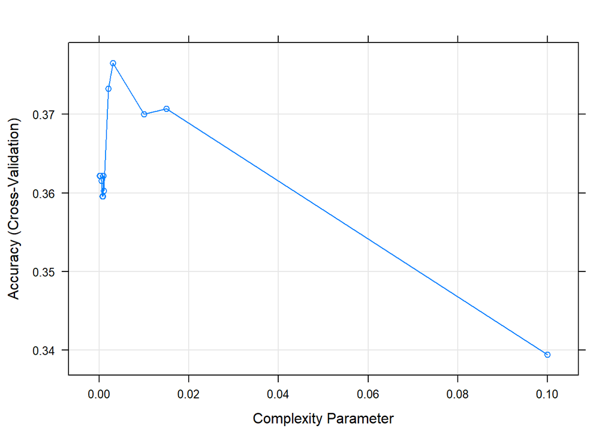

```r
plot(tree_model)
```

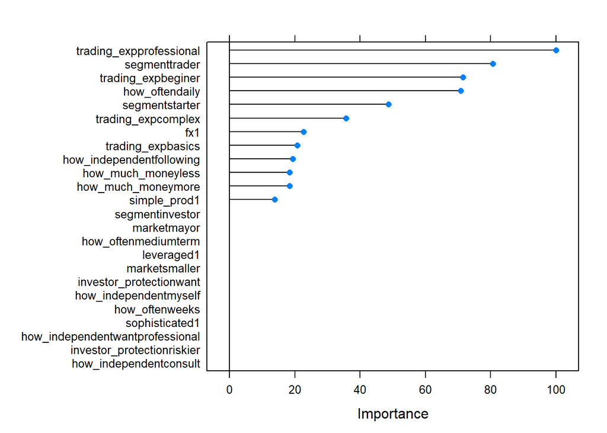

```r
plot(varImp(tree_model))
```

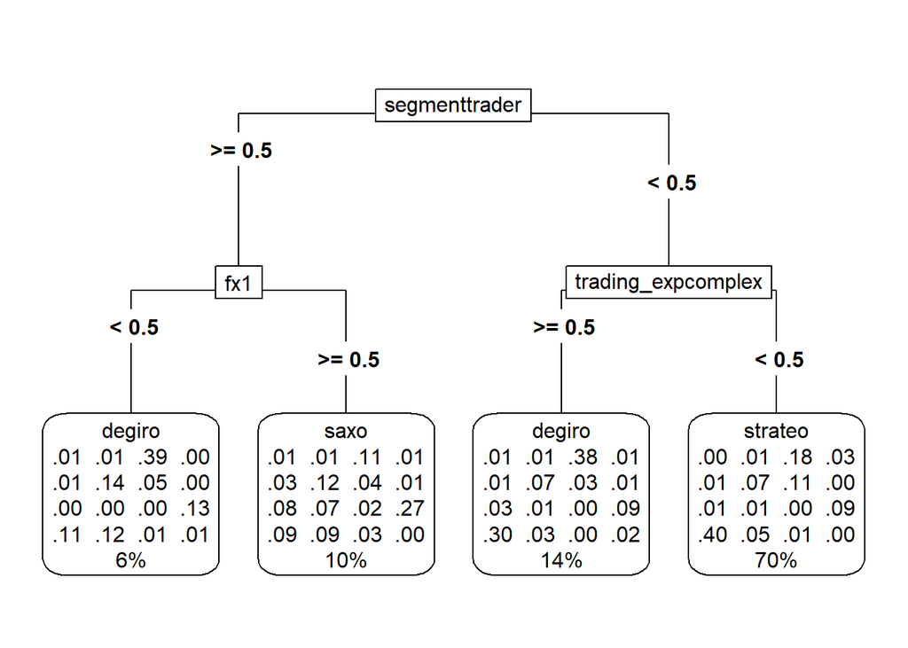

```r
rpart.plot(tree_model$finalModel, box.palette=0, type = 5)
```

### RandomForest on one-hot-encoded data:

- exactly the same results than without one-hot encoded the variables. Looks like Caret does it for us.

```r
train_control <- trainControl(method = "cv",
                              number = 5,
                              classProbs = TRUE)
```

```r
rf_model <- train(broker ~ .,
                  method = "rf",
                  data = data_train_one_hot,
                  trControl = train_control,
                  tuneGrid = data.frame(mtry = c(2, 3, 4, 5)),
                  importance = T)
```

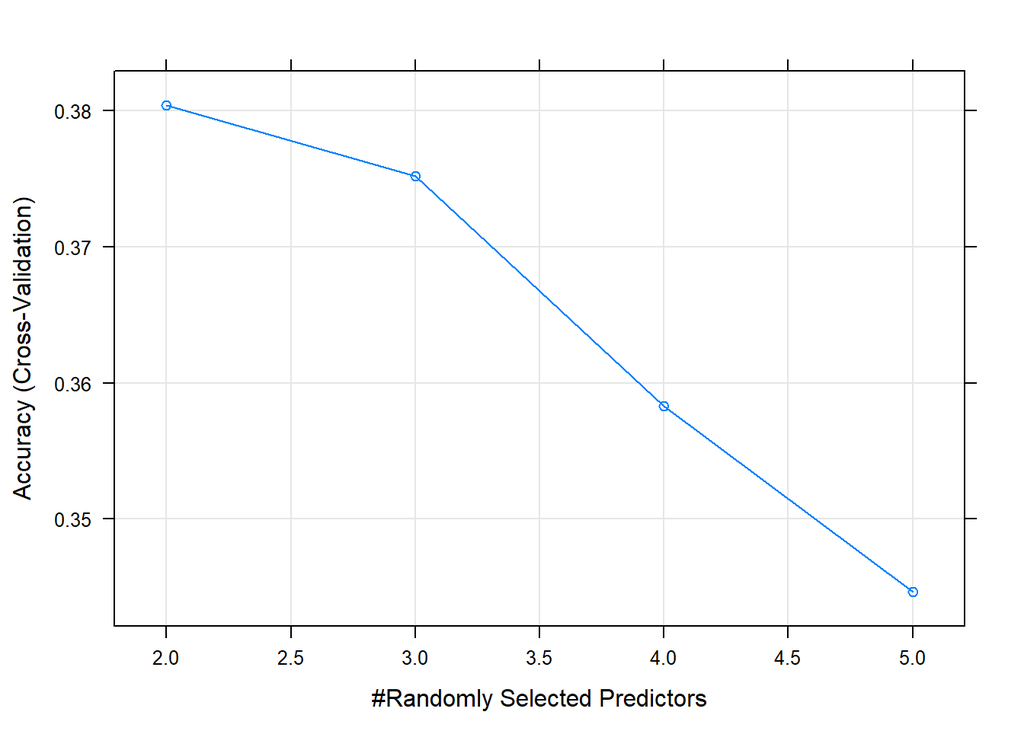

```r
plot(rf_model)
```

```r
rf_model
```

```
## Random Forest
##
## 1535 samples
##   24 predictor
##   16 classes: 'bgl', 'comdirect', 'degiro', 'etoro', 'ig_com', 'interactive', 'internaxx', 'markets_com', 'oanda', 'peperstone', 'plus500', 'saxo', 'strateo', 'swiss', 'tastyworks', 'tradestation'
##
## No pre-processing
## Resampling: Cross-Validated (5 fold)
## Summary of sample sizes: 1228, 1229, 1228, 1226, 1229
## Resampling results across tuning parameters:
##
##   mtry  Accuracy   Kappa
##   2     0.3804397  0.1132075
##   3     0.3752364  0.1198729
##   4     0.3582748  0.1077511
##   5     0.3446172  0.1016841
##
## Accuracy was used to select the optimal model using the largest value.
## The final value used for the model was mtry = 2.
```

### Multinomial Logit

Itt csináltam meg azt a modellt amit kihagytam az előző pontban. Nevezetesen a multinomiális logit modellt. Ez sem add valami szép eredményt, de lefut.

Ha segítesz értelmezni az egyes lépéseket azt megköszönöm.

```r
require(foreign)
```

```r
require(nnet)
require(ggplot2)
require(reshape2)
#source:
# https://stats.idre.ucla.edu/r/dae/multinomial-logistic-regression/
```

```r
colnames(data_one_hot)
```

```
##  [1] "segmentinvestor"                 "segmentstarter"
##  [3] "segmenttrader"                   "how_independentconsult"
##  [5] "how_independentfollowing"        "how_independentmyself"
##  [7] "how_independentwantprofessional" "trading_expbasics"
##  [9] "trading_expbeginer"              "trading_expcomplex"
## [11] "trading_expprofessional"         "how_much_moneyless"
## [13] "how_much_moneymore"              "how_oftendaily"
## [15] "how_oftenmediumterm"             "how_oftenweeks"
## [17] "marketmayor"                     "marketsmaller"
## [19] "simple_prod"                     "sophisticated"
## [21] "leveraged"                       "fx"
## [23] "investor_protectionriskier"      "investor_protectionwant"
## [25] "broker"
```

```r
with(data_one_hot, do.call(rbind, tapply(segmentinvestor, broker, function(x) c(M = mean(x), SD = sd(x)))))
```

```
##                       M        SD
## bgl          0.36363636 0.5045250
## comdirect    0.16000000 0.3741657
## degiro       0.27469880 0.4469011
## etoro        0.15217391 0.3631584
## ig_com       0.19047619 0.4023739
## interactive  0.27922078 0.4500799
## internaxx    0.11695906 0.3223153
## markets_com  0.18181818 0.4045199
## oanda        0.18750000 0.3965578
## peperstone   0.08695652 0.2881041
## plus500      0.00000000 0.0000000
## saxo         0.22330097 0.4174730
## strateo      0.25960061 0.4387526
## swiss        0.27522936 0.4486927
## tastyworks   0.14285714 0.3585686
## tradestation 0.45454545 0.5222330
```

Before running our model. We then choose the level of our outcome that we wish to use as our baseline and specify this in the relevel function. Then, we run our model using multinom. The multinom package does not include p-value calculation for the regression coefficients, so we calculate p-values using Wald tests (here z-tests).

```r
data_one_hot$broker <- relevel(data_one_hot$broker, ref = "degiro")

summary(data_one_hot$broker)
```

```
##       degiro          bgl    comdirect        etoro       ig_com
##          415           11           25           46           21
##  interactive    internaxx  markets_com        oanda   peperstone
##          154          171           11           32           23
##      plus500         saxo      strateo        swiss   tastyworks
##            6          206          651          109           21
## tradestation
##           11
```

Test and train split (80-20)

```r
train_indices <- createDataPartition(y = data_one_hot$broker,
                                     times = 1,
                                     p = 0.8,
                                     list = FALSE)

data_train_one_hot <- data_one_hot[train_indices, ]
data_test_one_hot <- data_one_hot[-train_indices, ]
```

```r
multilogit <- multinom(broker ~ ., data = data_train_one_hot, maxit = 10000)
summary(multilogit)
```

```
## Call:
## multinom(formula = broker ~ ., data = data_train_one_hot, maxit = 10000)
##
## Coefficients:
##                (Intercept) segmentinvestor segmentstarter segmenttrader
## bgl           -0.681703773      0.38052678    -1.09245203    0.03022147
## comdirect     -2.561748957     -1.14153236    -1.26420350   -0.15601309
## etoro         -0.692207179     -0.63467670     0.32367888   -0.38120935
## ig_com        -2.544028313     -1.46245615    -0.59023098   -0.49134118
## interactive   -0.148920085     -0.31355239    -0.19138785    0.35602016
## internaxx     -0.593369175     -0.48541093     0.08361586   -0.19157411
## markets_com   -4.453763560     -1.40298113    -1.51993667   -1.53084576
## oanda         -3.079563714     -0.88819854    -0.87223432   -1.31913086
## peperstone    -4.338118061     -2.31090651    -1.24234845   -0.78486311
## plus500      -13.340552391    -11.48415835    -1.02748504   -0.82890900
## saxo          -0.006531363     -0.22630424    -0.31949821    0.53927108
## strateo        0.009232654     -0.01030365     0.10168405   -0.08214774
## swiss         -1.977527271     -1.04296637    -1.02723810    0.09267720
## tastyworks    -0.688892718     -1.28020066     0.07488023    0.51642771
## tradestation  -5.789150544     -2.79842764    -1.52619928   -1.46452362
##              how_independentconsult how_independentfollowing
## bgl                     -0.35222581               -0.1519524
## comdirect                3.79658653                5.2849987
## etoro                   -1.58509953                2.1922930
## ig_com                   4.88135684                4.9928457
## interactive             -0.01650671               -0.6187232
## internaxx               -1.39962789                0.7054870
## markets_com              3.70447686                5.1086423
## oanda                    8.29870248               -7.2319031
## peperstone               4.16983031                5.0169763
## plus500                  8.76962493              -15.0933129
## saxo                    -0.10481226                0.5011345
## strateo                 -0.30792436                0.2609451
## swiss                    5.96431474                5.0371301
## tastyworks              -1.56100869               -0.2888263
## tradestation            -3.81424975               -4.2752101
##              how_independentmyself how_independentwantprofessional
## bgl                   -1.461428799                       1.2839032
## comdirect              4.964012755                     -16.6073470
## etoro                 -1.549137770                       0.2497372
```

[output cut: 226 more lines]

```
## ig_com       0.6606541               4.539629e-01               0.3769643
## interactive  0.3229851               1.713514e-01               0.1491022
## internaxx    0.3609156               1.733086e-01               0.1549263
## markets_com  0.9990265               9.378523e+00               9.3749823
## oanda        0.7032929               3.370745e-01               0.2830832
## peperstone   0.6973143               3.295791e-01               0.2964063
## plus500      1.1871390               2.661524e-08               0.2974587
## saxo         0.2953749               1.467490e-01               0.1296295
## strateo      0.2590065               1.204527e-01               0.1053460
## swiss        0.3610728               1.785121e-01               0.1626941
## tastyworks   0.8085431               3.846938e-01               0.3389766
## tradestation 1.3406751               1.014612e+01              10.1441447
##
## Residual Deviance: 5224.991
## AIC: 5764.991
```

```r
z <- summary(multilogit)$coefficients/summary(multilogit)$standard.errors
z
```

```
##               (Intercept) segmentinvestor segmentstarter segmenttrader
## bgl           -2.23793302    5.425811e-01     -1.3451856    0.03553603
## comdirect     -7.74587996   -2.022694e+00     -2.6284080   -0.26831466
## etoro         -3.12275160   -1.246043e+00      0.6787922   -0.58030261
## ig_com       -10.03525577   -2.440241e+00     -1.1721991   -0.86555417
## interactive   -1.23936999   -1.316251e+00     -0.8371209    1.32509385
## internaxx     -3.53932062   -1.709305e+00      0.3350569   -0.55959461
## markets_com   -0.23774834   -2.229341e-01     -0.2412886   -0.24252575
## oanda        -14.12950281   -1.459703e+00     -1.6916328   -2.69167594
## peperstone   -21.93015836   -3.218104e+00     -2.1699167   -1.30761724
## plus500      -44.84841691   -7.107938e+05     -1.2501239   -0.97272282
## saxo          -0.06000463   -1.044843e+00     -1.5364232    2.24770146
## strateo        0.09377765   -5.806250e-02      0.6019875   -0.34744216
## swiss        -15.06116783   -3.901660e+00     -4.3084103    0.31556569
## tastyworks    -2.63911586   -1.932912e+00      0.1363980    0.82902261
## tradestation  -0.28560718   -4.111028e-01     -0.2235793   -0.21480838
##              how_independentconsult how_independentfollowing
## bgl                     -0.47586557            -1.708527e-01
## comdirect                6.72522979             1.036890e+01
## etoro                   -2.46449530             5.191695e+00
## ig_com                   7.81231166             6.488879e+00
## interactive             -0.05536659            -1.343959e+00
## internaxx               -3.42815308             1.854247e+00
## markets_com              0.59053883             8.152066e-01
## oanda                   17.99173149            -5.285051e+07
## peperstone               5.21108272             6.299482e+00
## plus500                 13.12640597            -4.931111e+11
## saxo                    -0.37260183             1.568125e+00
## strateo                 -1.53685040             1.075830e+00
## swiss                   22.54431053             1.264768e+01
## tastyworks              -1.79552943            -3.293789e-01
## tradestation            -0.04522106            -4.850401e-01
##              how_independentmyself how_independentwantprofessional
## bgl                    -2.31339817                    1.244357e+00
## comdirect              13.43005592                             NaN
## etoro                  -3.12057682                    2.699091e-01
## ig_com                 11.73131488                   -1.387906e+11
## interactive            -0.82530880                    1.211499e+00
## internaxx               1.97626161                   -5.792144e-01
## markets_com             0.49723871                   -8.210704e+05
```

[output cut: 89 more lines]

```
## bgl                       -1.1870046
## comdirect                 -4.2556290
## etoro                     -1.0919459
## ig_com                    -2.6394001
## interactive               -0.6640641
## internaxx                 -3.1268840
## markets_com               -0.2329854
## oanda                     -5.0347464
## peperstone                -7.8429520
## plus500                   10.8887484
## saxo                      -1.2164233
## strateo                   -0.7180451
## swiss                     -7.1660650
## tastyworks                -1.0821608
## tradestation              -0.2893084
```

2-tailed z test

```r
p <- (1 - pnorm(abs(z), 0, 1)) * 2
p
```

```
##               (Intercept) segmentinvestor segmentstarter segmenttrader
## bgl          2.522542e-02    5.874183e-01   1.785653e-01   0.971652318
## comdirect    9.547918e-15    4.310472e-02   8.578557e-03   0.788457127
## etoro        1.791689e-03    2.127486e-01   4.972696e-01   0.561710565
## ig_com       0.000000e+00    1.467746e-02   2.411171e-01   0.386734696
## interactive  2.152085e-01    1.880898e-01   4.025246e-01   0.185140027
## internaxx    4.011583e-04    8.739440e-02   7.375822e-01   0.575755979
## markets_com  8.120763e-01    8.235868e-01   8.093315e-01   0.808372803
## oanda        0.000000e+00    1.443716e-01   9.071601e-02   0.007109399
## peperstone   0.000000e+00    1.290409e-03   3.001316e-02   0.191003167
## plus500      0.000000e+00    0.000000e+00   2.112543e-01   0.330691079
## saxo         9.521519e-01    2.960955e-01   1.244346e-01   0.024595233
## strateo      9.252858e-01    9.536988e-01   5.471824e-01   0.728259168
## swiss        0.000000e+00    9.553545e-05   1.644321e-05   0.752332186
## tastyworks   8.312257e-03    5.324705e-02   8.915067e-01   0.407091616
## tradestation 7.751790e-01    6.809972e-01   8.230847e-01   0.829916718
##              how_independentconsult how_independentfollowing
## bgl                    6.341701e-01             8.643396e-01
## comdirect              1.753153e-11             0.000000e+00
## etoro                  1.372064e-02             2.083885e-07
## ig_com                 5.551115e-15             8.647749e-11
## interactive            9.558464e-01             1.789618e-01
## internaxx              6.077027e-04             6.370381e-02
## markets_com            5.548295e-01             4.149541e-01
## oanda                  0.000000e+00             0.000000e+00
## peperstone             1.877417e-07             2.986420e-10
## plus500                0.000000e+00             0.000000e+00
## saxo                   7.094448e-01             1.168519e-01
## strateo                1.243299e-01             2.820032e-01
## swiss                  0.000000e+00             0.000000e+00
## tastyworks             7.256939e-02             7.418693e-01
## tradestation           9.639311e-01             6.276479e-01
##              how_independentmyself how_independentwantprofessional
## bgl                    0.020700757                     0.213368341
## comdirect              0.000000000                             NaN
## etoro                  0.001804972                     0.787230185
## ig_com                 0.000000000                     0.000000000
## interactive            0.409196295                     0.225704263
## internaxx              0.048125155                     0.562444500
## markets_com            0.619020725                     0.000000000
```

[output cut: 89 more lines]

```
## bgl                     2.352258e-01
## comdirect               2.084621e-05
## etoro                   2.748569e-01
## ig_com                  8.305290e-03
## interactive             5.066493e-01
## internaxx               1.766696e-03
## markets_com             8.157728e-01
## oanda                   4.784819e-07
## peperstone              4.440892e-15
## plus500                 0.000000e+00
## saxo                    2.238237e-01
## strateo                 4.727295e-01
## swiss                   7.718270e-13
## tastyworks              2.791811e-01
## tradestation            7.723454e-01
```

The ratio of the probability of choosing one outcome category over the probability of choosing the baseline category is often referred as relative risk (and it is also sometimes referred as odds as we have just used to described the regression parameters above). The relative risk is the right-hand side linear equation exponentiated, leading to the fact that the exponentiated regression coefficients are relative risk ratios for a unit change in the predictor variable. We can exponentiate the coefficients from our model to see these risk ratios.

```r
exp(coef(multilogit))
```

```
##               (Intercept) segmentinvestor segmentstarter segmenttrader
## bgl          5.057546e-01    1.463055e+00      0.3353931     1.0306828
## comdirect    7.716966e-02    3.193293e-01      0.2824642     0.8555480
## etoro        5.004702e-01    5.301068e-01      1.3822034     0.6830349
## ig_com       7.854934e-02    2.316666e-01      0.5541993     0.6118053
## interactive  8.616380e-01    7.308461e-01      0.8258122     1.4276363
## internaxx    5.524628e-01    6.154442e-01      1.0872112     0.8256584
## markets_com  1.163470e-02    2.458629e-01      0.2187257     0.2163526
## oanda        4.597931e-02    4.113962e-01      0.4180165     0.2673676
## peperstone   1.306109e-02    9.917131e-02      0.2887054     0.4561821
## plus500      1.607947e-06    1.029185e-05      0.3579059     0.4365253
## saxo         9.934899e-01    7.974754e-01      0.7265135     1.7147565
## strateo      1.009275e+00    9.897493e-01      1.1070336     0.9211359
## swiss        1.384111e-01    3.524078e-01      0.3579943     1.0971075
## tastyworks   5.021318e-01    2.779815e-01      1.0777551     1.6760297
## tradestation 3.060581e-03    6.090575e-02      0.2173602     0.2311881
##              how_independentconsult how_independentfollowing
## bgl                    7.031213e-01             8.590292e-01
## comdirect              4.454886e+01             1.973539e+02
## etoro                  2.049274e-01             8.955725e+00
## ig_com                 1.318094e+02             1.473552e+02
## interactive            9.836288e-01             5.386317e-01
## internaxx              2.466887e-01             2.024832e+00
## markets_com            4.062879e+01             1.654456e+02
## oanda                  4.018655e+03             7.231433e-04
## peperstone             6.470447e+01             1.509542e+02
## plus500                6.435758e+03             2.786490e-07
## saxo                   9.004936e-01             1.650593e+00
## strateo                7.349709e-01             1.298156e+00
## swiss                  3.892862e+02             1.540273e+02
## tastyworks             2.099242e-01             7.491423e-01
## tradestation           2.205425e-02             1.390913e-02
##              how_independentmyself how_independentwantprofessional
## bgl                      0.2319047                    3.610706e+00
## comdirect              143.1671395                    6.130852e-08
## etoro                    0.2124311                    1.283688e+00
## ig_com                 213.5646880                    1.893657e-08
## interactive              0.8121321                    2.002511e+00
## internaxx                1.8602820                    5.945465e-01
## markets_com             22.5571611                    7.673290e-08
```

[output cut: 89 more lines]

```
## bgl                       0.60586416
## comdirect                 0.25124261
## etoro                     0.75515751
## ig_com                    0.36973834
## interactive               0.90573057
## internaxx                 0.61604420
## markets_com               0.11256396
## oanda                     0.24044788
## peperstone                0.09781276
## plus500                  25.50700861
## saxo                      0.85411932
## strateo                   0.92714696
## swiss                     0.31164948
## tastyworks                0.69292941
## tradestation              0.05314207
```

You can also use predicted probabilities to help you understand the model. You can calculate predicted probabilities for each of our outcome levels using the fitted function. We can start by generating the predicted probabilities for the observations in our dataset and viewing the first few rows

```r
head(pp <- fitted(multilogit))
```

```
##      degiro         bgl  comdirect       etoro      ig_com interactive
## 1 0.2341671 0.004771194 0.03798252 0.112982466 0.001688620  0.01866595
## 2 0.3255849 0.001790883 0.03831067 0.003726205 0.003402785  0.03913121
## 3 0.3255849 0.001790883 0.03831067 0.003726205 0.003402785  0.03913121
## 4 0.3255849 0.001790883 0.03831067 0.003726205 0.003402785  0.03913121
## 5 0.2557140 0.004322433 0.09113621 0.001446198 0.002950340  0.05313121
## 6 0.2557140 0.004322433 0.09113621 0.001446198 0.002950340  0.05313121
##   internaxx markets_com        oanda peperstone      plus500       saxo
## 1 0.1585453 0.017607791 6.427625e-10 0.01385873 3.708571e-29 0.12343214
## 2 0.2025263 0.003337894 4.472468e-03 0.01814202 2.614993e-19 0.08421182
## 3 0.2025263 0.003337894 4.472468e-03 0.01814202 2.614993e-19 0.08421182
## 4 0.2025263 0.003337894 4.472468e-03 0.01814202 2.614993e-19 0.08421182
## 5 0.1207975 0.002593134 2.246740e-03 0.02251433 2.504962e-19 0.15610687
## 6 0.1207975 0.002593134 2.246740e-03 0.02251433 2.504962e-19 0.15610687
##     strateo      swiss  tastyworks tradestation
## 1 0.2434151 0.02401472 0.008868378 1.441123e-15
## 2 0.2032182 0.05577127 0.016373399 1.412596e-10
## 3 0.2032182 0.05577127 0.016373399 1.412596e-10
## 4 0.2032182 0.05577127 0.016373399 1.412596e-10
## 5 0.1328054 0.13423746 0.019998188 1.180032e-10
## 6 0.1328054 0.13423746 0.019998188 1.180032e-10
```

```r
logit_prediction_train <- predict(multilogit, newdata = data_train_one_hot)

logit_prediction_test <-  predict(multilogit, newdata = data_test_one_hot)
data_test_one_hot$predicted_multi <- predict(multilogit, newdata = data_test_one_hot)
```

```r
accuracy_help_test <- ifelse(as.character(data_test_one_hot$broker) == as.character(logit_prediction_test), 1, 0)
accuracy_help_train <- ifelse(as.character(data_train_one_hot$broker) == as.character(logit_prediction_train), 1, 0)
### Accuracy train
sum(accuracy_help_train)/length(data_train_one_hot$broker)
```

```
## [1] 0.4039088
```

```r
### Accuracy test
sum(accuracy_help_test)/length(data_test_one_hot$broker)
```

```
## [1] 0.3809524
```

```r
confusionMatrix(data_test_one_hot$predicted_multi, data_test_one_hot$broker)
```

```
## Confusion Matrix and Statistics
##
##               Reference
## Prediction     degiro bgl comdirect etoro ig_com interactive internaxx
##   degiro           30   0         1     1      0           3         2
##   bgl               0   0         0     0      0           0         0
##   comdirect         0   0         0     0      0           0         0
##   etoro             0   0         0     1      0           2         0
##   ig_com            0   0         0     0      0           0         0
##   interactive       1   0         0     0      0           2         0
##   internaxx         0   0         0     0      0           0         2
##   markets_com       0   0         0     0      0           0         0
##   oanda             1   0         0     0      0           0         0
##   peperstone        0   0         0     0      0           0         0
##   plus500           0   0         0     0      0           0         0
##   saxo              4   1         0     0      0           2         0
##   strateo          45   1         4     7      3          21        30
##   swiss             2   0         0     0      1           0         0
##   tastyworks        0   0         0     0      0           0         0
##   tradestation      0   0         0     0      0           0         0
##               Reference
## Prediction     markets_com oanda peperstone plus500 saxo strateo swiss
##   degiro                 1     2          0       0    2      19     0
##   bgl                    0     0          0       0    0       0     0
##   comdirect              0     0          0       0    0       0     0
##   etoro                  0     0          0       0    1       1     0
##   ig_com                 0     0          0       0    0       0     0
##   interactive            0     1          1       0    5       2     0
##   internaxx              0     0          0       0    0       2     0
##   markets_com            0     0          0       0    0       0     0
##   oanda                  0     2          0       0    0       2     0
##   peperstone             0     0          0       0    0       0     0
##   plus500                0     0          0       0    0       0     0
##   saxo                   1     1          1       0    4       1     5
##   strateo                0     0          2       1   28     102    15
##   swiss                  0     0          0       0    1       1     1
##   tastyworks             0     0          0       0    0       0     0
##   tradestation           0     0          0       0    0       0     0
##               Reference
## Prediction     tastyworks tradestation
```

[output cut: 68 more lines]

```
## Pos Pred Value               0.3878     0.166667               NaN
## Neg Pred Value               0.7565     0.946237           0.98942
## Prevalence                   0.3439     0.055556           0.01058
## Detection Rate               0.2698     0.002646           0.00000
## Detection Prevalence         0.6958     0.015873           0.00000
## Balanced Accuracy            0.5677     0.516807           0.50000
##                      Class: tradestation
## Sensitivity                     0.000000
## Specificity                     1.000000
## Pos Pred Value                       NaN
## Neg Pred Value                  0.994709
## Prevalence                      0.005291
## Detection Rate                  0.000000
## Detection Prevalence            0.000000
## Balanced Accuracy               0.500000
```